# 11 Session 11: Area Data III

# Practice questions

Answer the following questions:

1. What does the 45 degree line in the scatterplot of spatial moving averages indicate?
2. What is the effect of centering a variable around the mean?
3. In your own words, describe the phenomenon of spatial autocorrelation.
4. What is the null hypothesis in the test of autocorrelation based on Moran’s I?

# Learning objectives

In this activity, you will:

1. Calculate Moran’s I coefficient of autocorrelation for area data.
2. Create Moran’s scatterplots.
3. Examine the results of the tests/scatterplots for further insights.
4. Think about ways to decide whether a landscape is random when working with area data.

# Suggested reading

O’Sullivan D and Unwin D (2010) Geographic Information Analysis, 2nd Edition, Chapter 7. John Wiley & Sons: New Jersey.

# Preliminaries

For this activity you will need the following:

- This R markdown notebook.
- A shape file called `Hamilton CMA CT`.

It is good practice to clear the working space to make sure that you do not have extraneous items there when you begin your work. The command in R to clear the workspace is `rm` (for “remove”), followed by a list of items to be removed. To clear the workspace from *all* objects, do the following:

```r
rm(list = ls())
```

Note that `ls()` lists all objects currently on the worspace.

```r
library(tidyverse)
library(rgdal)
library(broom)
library(spdep)
```

Begin by loading the data that you will use in this activity:

```r
Hamilton_CT <- readOGR(".", layer = "Hamilton CMA CT", integer64 = "allow.loss")
```

You can obtain new (calculated) variables as follows. For instance, to obtain the proportion of residents who are between 20 and 34 years old, and between 35 and 49:

```r
Hamilton_CT@data <- mutate(Hamilton_CT@data, Prop20to34 = (AGE_20_TO_ + AGE_25_TO_ + AGE_30_TO_)/POPULATION, Prop35to49 = (AGE_35_TO_ + AGE_40_TO_ + AGE_45_TO_)/POPULATION)
```

Example: Proportion of residents who are between 20 and 34 years old, and between 35 and 49:

```r
Hamilton_CT@data <- dplyr::transmute(Hamilton_CT@data, AREA = AREA, TRACT = TRACT,
                                     POPULATION = POPULATION,
                                     POP20to34 = (AGE_20_TO_ + AGE_25_TO_ + AGE_30_TO_),
                                     Prop20to34 = POP20to34/POPULATION,
                                     POP35to49 = (AGE_35_TO_ + AGE_40_TO_ + AGE_45_TO_),
                                     Prop35to49 = POP35to49/POPULATION,
                                     POP50to64 = (AGE_50_TO_ + AGE_55_TO_ + AGE_60_TO_),
                                     Prop50to64 = POP50to64/POPULATION,
                                     POP65Plus = (AGE_65_TO_ + AGE_70_TO_ + AGE_75_TO_ + AGE_80_TO_ + AGE_85),
                                     Prop65Plus = POP65Plus/POPULATION)
```

This is a `SpatialPolygonDataFrame`. Convert to a dataframe (“tidy” it) for plotting using `ggplot2`:

```r
Hamilton_CT.t <- tidy(Hamilton_CT, region = "TRACT")
Hamilton_CT.t <- rename(Hamilton_CT.t, TRACT = id)
```

Rejoin the data:

```r
Hamilton_CT.t <- left_join(Hamilton_CT.t, Hamilton_CT@data, by = "TRACT")
```

```
Column `TRACT` joining character vector and factor, coercing into character vector
```

# Activity

1. Create a spatial weights matrix for the census tracts in the Hamilton CMA.

```r
Hamilton_CT.w <- nb2listw(poly2nb(pl = Hamilton_CT))
```

2. Use `moran.test` to test the following variables for autocorrelation: proportion of the population who are 20 to 34 years old, 35 to 49 years old, 50 to 65 years old, and 65 and older. How confident are you deciding whether these variables are not spatially random? What can you say regarding the relative strength of these variables’ spatial patterns?

```r
moran.test(Hamilton_CT$Prop20to34, Hamilton_CT.w)
```

```
    Moran I test under randomisation

data:  Hamilton_CT$Prop20to34
weights: Hamilton_CT.w

Moran I statistic standard deviate = 9.4183, p-value < 2.2e-16
alternative hypothesis: greater
sample estimates:
Moran I statistic       Expectation          Variance
      0.383862248      -0.005347594       0.001707738
```

```r
moran.test(Hamilton_CT$Prop35to49, Hamilton_CT.w)
```

```
    Moran I test under randomisation

data:  Hamilton_CT$Prop35to49
weights: Hamilton_CT.w

Moran I statistic standard deviate = 5.0789, p-value = 1.898e-07
alternative hypothesis: greater
sample estimates:
Moran I statistic       Expectation          Variance
      0.200254211      -0.005347594       0.001638775
```

```r
moran.test(Hamilton_CT$Prop50to64, Hamilton_CT.w)
```

```
    Moran I test under randomisation

data:  Hamilton_CT$Prop50to64
weights: Hamilton_CT.w

Moran I statistic standard deviate = 4.9735, p-value = 3.288e-07
alternative hypothesis: greater
sample estimates:
Moran I statistic       Expectation          Variance
      0.197540572      -0.005347594       0.001664146
```

```r
moran.test(Hamilton_CT$Prop65Plus, Hamilton_CT.w)
```

```
    Moran I test under randomisation

data:  Hamilton_CT$Prop65Plus
weights: Hamilton_CT.w

Moran I statistic standard deviate = 5.3758, p-value = 3.811e-08
alternative hypothesis: greater
sample estimates:
Moran I statistic       Expectation          Variance
      0.218470626      -0.005347594       0.001733395
```

3. Use `moran.plot` to create Moran’s scatterplots to complement your tests of spatial autocorrelation. Discuss the patterns that you observe.

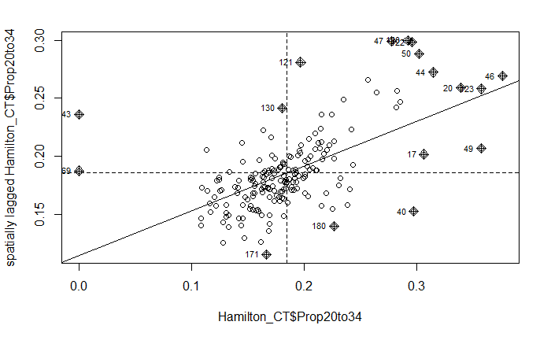

```r
mp1 <- moran.plot(Hamilton_CT$Prop20to34, Hamilton_CT.w)
```

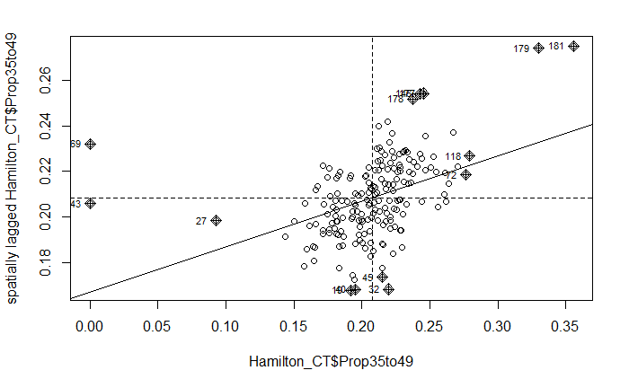

```r
mp2 <- moran.plot(Hamilton_CT$Prop35to49, Hamilton_CT.w)
```

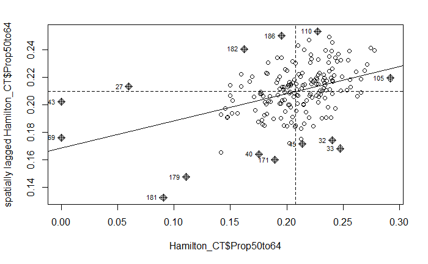

```r
mp3 <- moran.plot(Hamilton_CT$Prop50to64, Hamilton_CT.w)
```

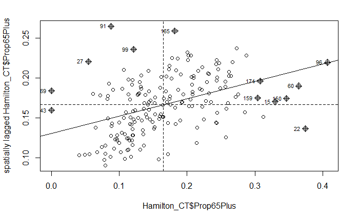

```r
mp4 <- moran.plot(Hamilton_CT$Prop65Plus, Hamilton_CT.w)
```

4. The scatterplots created using `moran.plot` include some observations that are labeled with their id and a different symbol. Why do you think these observations are highlighted in such a way?